# A5

Girim Ban, Vivi Wang, Jason Hu, Benjamin Yellowshirt

04/03/2019

** PART 6 **

```r
library(readr)
AmesTrain12 <- read_csv("AmesTrain12.csv")
View(AmesTrain12)
HomeData = select_if(AmesTrain12, is.numeric)
HomeData = select(HomeData, -c(Order))
View(HomeData)


library(readr)
AmesTest12 <- read_csv("AmesTest12.csv")
View(AmesTest12)
```

```r
BasicModel=lm(Price~GroundSF+YearBuilt+BasementSF+GarageSF+YearRemodel+Fireplaces+Bedroom+LotFrontage+LotArea+BasementFBath, data=HomeData)
summary(BasicModel)
```

```
##
## Call:
## lm(formula = Price ~ GroundSF + YearBuilt + BasementSF + GarageSF +
##     YearRemodel + Fireplaces + Bedroom + LotFrontage + LotArea +
##     BasementFBath, data = HomeData)
##
## Residuals:
##     Min      1Q  Median      3Q     Max
## -141.62  -19.02   -1.34   15.64  167.03
##
## Coefficients:
##                 Estimate Std. Error t value Pr(>|t|)
## (Intercept)   -2.021e+03  1.475e+02 -13.701  < 2e-16 ***
## GroundSF       6.628e-02  4.401e-03  15.060  < 2e-16 ***
## YearBuilt      5.179e-01  5.925e-02   8.741  < 2e-16 ***
## BasementSF     4.131e-02  4.276e-03   9.661  < 2e-16 ***
## GarageSF       5.837e-02  7.923e-03   7.368 5.90e-13 ***
## YearRemodel    5.102e-01  8.512e-02   5.994 3.57e-09 ***
## Fireplaces     1.104e+01  2.624e+00   4.208 2.98e-05 ***
## Bedroom       -8.435e+00  2.184e+00  -3.863 0.000125 ***
## LotFrontage    1.505e-01  4.216e-02   3.571 0.000385 ***
## LotArea        3.266e-04  1.085e-04   3.012 0.002710 **
## BasementFBath  7.891e+00  2.822e+00   2.796 0.005348 **
## ---
## Signif. codes:  0 '***' 0.001 '**' 0.01 '*' 0.05 '.' 0.1 ' ' 1
##
## Residual standard error: 32.8 on 589 degrees of freedom
## Multiple R-squared:  0.8152, Adjusted R-squared:  0.8121
## F-statistic: 259.9 on 10 and 589 DF,  p-value: < 2.2e-16
```

```r
fitHousingPrice=predict(BasicModel, newdata=AmesTest12)
fitHousingPrice
```

```
##         1         2         3         4         5         6         7
## 144.41955 219.74213 274.15382 359.34703 259.71951 219.74934 127.66597
##         8         9        10        11        12        13        14
## 260.69634 197.02180 184.43644 153.34532 195.60422 160.04038 132.62204
##        15        16        17        18        19        20        21
## 105.59145  55.12655 291.71252 235.93571 184.22942 315.23129 119.18002
##        22        23        24        25        26        27        28
## 299.82414 121.44729 270.48126 102.77690 118.81015 137.99360 170.18679
##        29        30        31        32        33        34        35
## 170.75852 261.20491 196.57005 174.59419 269.88949 129.52570 195.45238
##        36        37        38        39        40        41        42
## 226.85681 152.63732 162.11760 142.23890 229.37629 245.08138 161.45100
##        43        44        45        46        47        48        49
##  92.17764 255.55813 224.20854 220.96659 284.48825 111.87673 272.06564
##        50        51        52        53        54        55        56
## 117.40753  83.55726 112.52885 147.53715 130.23223 116.56626 176.30610
##        57        58        59        60        61        62        63
## 149.20408 107.88020 204.15837 229.45361  96.96668 218.31264 125.12015
##        64        65        66        67        68        69        70
## 121.08496 202.87911 136.16806 195.30948 131.09504 138.09559  65.75435
##        71        72        73        74        75        76        77
## 177.72011 270.14154 298.97294 341.21305 171.95118 267.29713 172.00517
##        78        79        80        81        82        83        84
## 183.93315 193.64893 183.71824 152.51060 136.86525 183.42404 128.05627
##        85        86        87        88        89        90        91
## 106.15767 195.84384 357.46641 305.27121 223.60847 101.62471 107.19560
##        92        93        94        95        96        97        98
## 137.99740 242.51587 224.40410 312.86354 113.10885 235.62940 153.16260
##        99       100       101       102       103       104       105
## 121.51946 327.57731 152.58599 145.81720 262.86240 286.44448 100.78505
##       106       107       108       109       110       111       112
## 223.01256 169.05197  32.55499 192.98782 111.90406 151.19143  99.00866
##       113       114       115       116       117       118       119
## 229.22841 183.59176 153.26106 183.74949 152.48745 147.31326 309.68603
##       120       121       122       123       124       125       126
## 159.82331 109.43808 131.36926 136.12686 102.29305 151.76044 260.66435
##       127       128       129       130       131       132       133
## 144.93491 238.97939 216.46271 294.19879  83.53816 269.17710 257.85876
##       134       135       136       137       138       139       140
## 156.15362 387.58028 207.70689 203.27815 308.41772 231.90246 209.50318
##       141       142       143       144       145       146       147
## 150.85357 104.29214 217.88241  72.76874 102.80090 123.82138 236.28025
##       148       149       150       151       152       153       154
## 220.16119 125.69070 157.04260 273.24594 166.69310  78.18744 223.69545
##       155       156       157       158       159       160       161
## 229.57886 134.13203 211.22171 351.69373 182.39561 119.10878 118.89422
##       162       163       164       165       166       167       168
## 139.92869 233.86515  97.01843 245.63269 139.51210 248.94467 157.26540
##       169       170       171       172       173       174       175
## 135.68469 248.14130 103.75681 307.64651 204.77511 185.48413 158.48933
##       176       177       178       179       180       181       182
## 256.05028 170.94002  90.56038 260.64661 313.56503 109.34772 346.90039
##       183       184       185       186       187       188       189
## 157.37444 131.25848  79.70045 112.40060 110.38386 255.88671 175.37988
##       190       191       192       193       194       195       196
##  17.55971 244.00790 264.70633 253.28643 257.26675  75.51015 135.78674
##       197       198       199       200
## 126.36546 144.90575 315.51603 275.75606
```

```r
summary(fitHousingPrice)
```

```
##    Min. 1st Qu.  Median    Mean 3rd Qu.    Max.
##   17.56  130.06  173.30  185.83  236.96  387.58
```

```r
holdoutResid= AmesTest12$Price - fitHousingPrice
holdoutResid
```

```
##            1            2            3            4            5
##    3.0804456   32.2578741   33.8761849   46.4019675   14.5804898
##            6            7            8            9           10
##  -25.0493373   34.0840343  -30.6963386  -12.0217999   -2.5364429
##           11           12           13           14           15
##   -7.0453155   11.8957809  -28.5403791   27.3779614   20.4085469
##           16           17           18           19           20
##   -3.1265475  -26.7125170   20.0642854   -8.2294195  -19.2312882
##           21           22           23           24           25
##  -17.1800168   72.5778592    8.5527119   22.7187430    5.7230977
##           26           27           28           29           30
##    6.1898460   -6.2435996  -37.1867921    3.2414849   -5.2049142
##           31           32           33           34           35
##  -72.5700547  -50.5941876  -21.5614870  -16.5256971   -6.5523788
##           36           37           38           39           40
##  -10.3568139   24.3626753  -47.1175959   13.7611050    4.8737093
##           41           42           43           44           45
##    2.9186214  -13.5509986   -1.1776390  -42.3081256  -17.2085361
##           46           47           48           49           50
## -110.9665896   47.5117540   -6.8767255  -43.0656413   32.4924717
##           51           52           53           54           55
##   54.4427360    7.4711480  -16.5371538   -6.3322268    2.2917378
##           56           57           58           59           60
##  -69.3061016  -37.2040776    7.1197997  -34.1683746    3.0463886
##           61           62           63           64           65
##  -28.5666834  -27.3126409   -7.1201503   30.4150395   22.1208933
##           66           67           68           69           70
##   -6.1680601  -65.3094832  -11.5950428    3.9044083   18.7456465
##           71           72           73           74           75
##    0.2798949   19.8584611  -38.9729398   57.5869459   15.5488211
##           76           77           78           79           80
##   57.7028725   30.4948265  -13.9481506  -63.6489274  -21.7182447
##           81           82           83           84           85
##   36.1894006   10.0347478   -3.0240400   12.9437283  -11.6576706
##           86           87           88           89           90
##  -35.8438429   28.7835896   72.7287922    4.8915314  -12.1247057
##           91           92           93           94           95
##   17.8043951   -0.9973974   -4.0158657  -32.4041036   10.3984564
##           96           97           98           99          100
##   12.7911493  -29.3293997   11.8373958   -1.0194629   97.4226866
```

[output cut: 25 more lines]

```
##   17.1057830   -5.4286890  -27.2851488   44.4815748  -36.1326868
##          166          167          168          169          170
##    2.4878973    3.7333257    7.7345999   17.9153142  -15.5413009
##          171          172          173          174          175
##   15.2431928    8.1034933  -32.2751084  -36.4841263    1.5106702
##          176          177          178          179          180
##  -25.5502764   14.0599786   -3.6603797   13.3533883   58.9349725
##          181          182          183          184          185
##    5.6522848   -4.9003862   -9.3744367   23.7415224   33.2995482
##          186          187          188          189          190
##   18.5994004   18.5661415  -20.8867089   14.6201217   26.4402937
##          191          192          193          194          195
##   30.9921046   53.2936658   26.7135711   43.7332543   20.9898513
##          196          197          198          199          200
##   -6.7867367  -41.3654567   -4.9057466   67.4839707    9.2439397
```

```r
mean(holdoutResid)
```

```
## [1] 1.474659
```

```r
sd(holdoutResid)
```

```
## [1] 28.67133
```

```r
mean(BasicModel$residuals)
```

```
## [1] 5.630623e-16
```

```r
sd(BasicModel$residuals)
```

```
## [1] 32.52651
```

```r
mean(holdoutResid) - mean(BasicModel$residuals)
```

```
## [1] 1.474659
```

```r
sd(holdoutResid) - sd(BasicModel$residuals)
```

```
## [1] -3.855183
```

** The mean of the holdout sample residuals is appproximately 1.5 larger than the training sample mean, which is expected, but the standard deviation of the holdout sample residuals is actually smaller than the training sample standard deviation by approximately 3.86, we expected both the mean and standard deviation to be a little larger for the holdout sample, but the standard deviation being smaller is a good thing because it hints that the model fits the holdout sample as well as it did the training sample. **

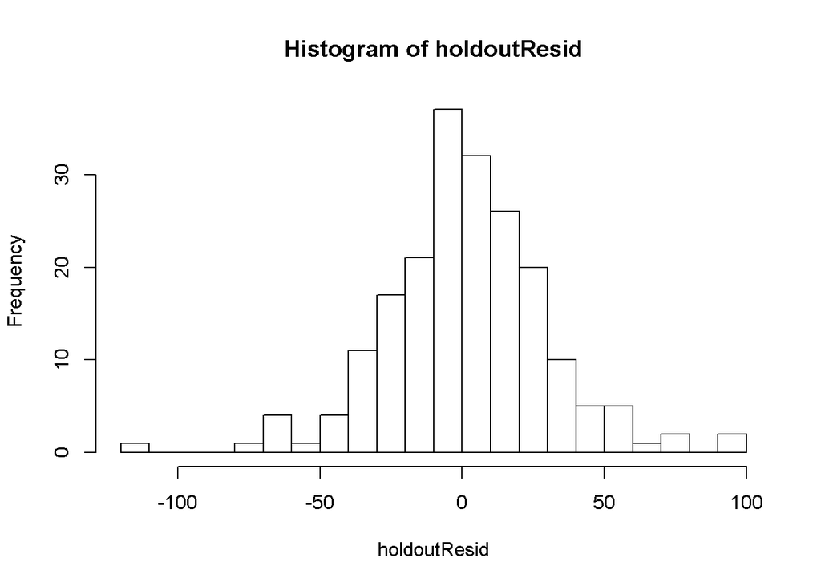

```r
hist(holdoutResid, breaks=15)
```

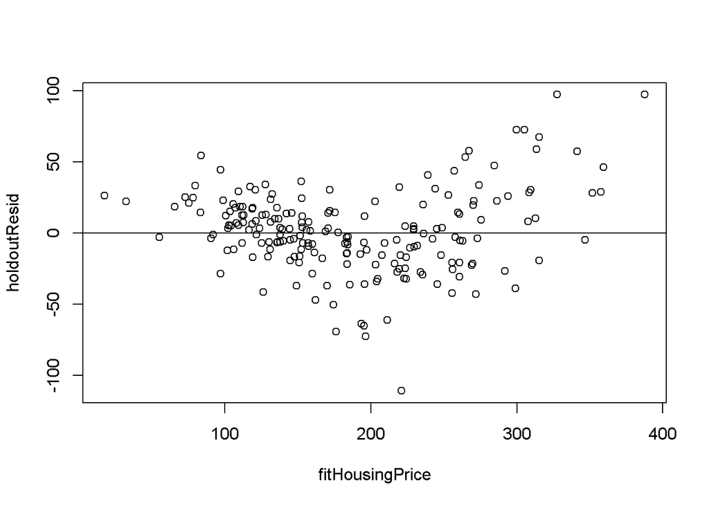

```r
plot(holdoutResid~fitHousingPrice)
abline(0,0)
```

```r
crosscor=cor(AmesTest12$Price,fitHousingPrice)
crosscor
```

```
## [1] 0.9349791
```

```r
crosscor^2
```

```
## [1] 0.8741858
```

```r
shrinkage = summary(BasicModel)$r.squared - crosscor^2
shrinkage
```

```
## [1] -0.05895722
```

** PART 7 **

```r
library(readr)
AmesTrain12 <- read_csv("AmesTrain12.csv")
View(AmesTrain12)

AllData = select(AmesTrain12, -c(Order))
View(AllData)
```

** SUMMARY **

Our first step was to create a model with all variables called “fullBasicModel”, from the summary of this model, we saw that there were 5 singularities, meaning there were variables that were collinear with other variables. We removed the five predictors that were related to other similar predictors and made a new model called “fullBasicModel3”.

We then transformed all bath variables into one variable and transformed all porch variables into one variable and made a new model called “fullFancyModel1”. We then took the summary of this model and took out all predictors that were insignificant with the exception of factored categorical predictors. The low vif values of the model’s predictors allowed us to do this step. We made a new model called “fullFancyModel2”.